# Relatório HATCO

### Bruno Oliveira Rocha e Rita Karen Alves Miranda

### 2017-10-04

## 1- Introdução

A vigente análise foi elaborada para auxiliar nos planos de ações da empresa “ Celular global HATCO”. Na atualidade as empresas não se podem dar o luxo de tomarem decisões sem estarem pautadas em informações sólidas, correndo assim o risco de gastar recursos com retorno mínimo. Portanto para uma boa tomada de decisão é preciso ter uma boa base de dados, informações confiáveis e relevantes. O objetivo da análise é apontar caminhos para os investimentos e focos de atuação, descartar variáveis que não são relevantes e dar bons recursos para a decisão das ações. seguida analisaremos os dados e apontaremos as variáveis mais relevantes e que trarão maior retorno e também as que devem ser desconsideradas.

## 2- Metodologia

O estudo foi pautado na base de dados: HATCO, os dados foram alinhados e colocados para utilização. Vários tipos de gráficos e análises foram feitas através do programa R, que permite uma ótima explanação de dados, visualização funcional e manipulação do mesmo. A busca foi pela variável mais importante denominada USO (que define o número de vendas de celulares), afinal o objetivo final da empresa é vender o maior número possível de celulares através da internet. A partir dela foram analisadas outras variáveis com nível de correlação que justificassem investimento e direcionamento de marketing. Descartamos as variáveis que possuíam menos de 50% em nível de correlação. Foi analisado uma amostra de 100 indivíduos. A base de dados possui 15 variáveis, são elas: Velocidade (Quantidade de tempo que leva para entregar o celular uma vez que uma ordem foi confirmada), preço (O valor do produto), flexibilidade (Percepção sobre a forma de pagamento (Dinheiro, Cartao, Crediário, em 10X, Desconto, etc)), imagem (imagem geral do fabricante/fornecedor), embalagem (Nível de qualidade percebido da embalagem), vendas (imagem geral da força da empresa de vendas), qualidade (nível de qualidade percebido de um determinado produto), empresa (tamanho da empresa em relação a outros neste mercado. Esta variável tem duas categorias: grande e pequena) ,uso (quantos celulares da empresa são comprados, medido em uma escala de porcentagem de 100 pontos, variando de 0 a 100%), satisfação (o grau de satisfação do usuário), internet (usuário eventual e usuário acostumado com a internet.), idade (esta variável tem duas categorias: Jovem; e Adulto), sexo (esta variável tem duas categorias: Feminino e Masculino) e local (Capital, Região Metropolitana e Interior).

### Resumo numérico da Base de dados

```r
summary(HATCO)
```

```
##        ID           Velocidade        Preço       Flexibilidade
##  Min.   :  1.00   Min.   :0.000   Min.   :0.200   Min.   : 5.000
##  1st Qu.: 25.75   1st Qu.:2.500   1st Qu.:1.475   1st Qu.: 6.700
##  Median : 50.50   Median :3.400   Median :2.150   Median : 8.050
##  Mean   : 50.50   Mean   :3.515   Mean   :2.364   Mean   : 7.894
##  3rd Qu.: 75.25   3rd Qu.:4.600   3rd Qu.:3.225   3rd Qu.: 9.100
##  Max.   :100.00   Max.   :6.100   Max.   :5.400   Max.   :10.000
##      Imagem        Embalagens        Vendas        Qualidade
##  Min.   :2.500   Min.   :0.700   Min.   :1.100   Min.   : 3.700
##  1st Qu.:4.575   1st Qu.:2.400   1st Qu.:2.200   1st Qu.: 5.800
##  Median :5.000   Median :3.000   Median :2.600   Median : 7.150
##  Mean   :5.248   Mean   :2.916   Mean   :2.665   Mean   : 6.971
##  3rd Qu.:6.000   3rd Qu.:3.425   3rd Qu.:3.000   3rd Qu.: 8.325
##  Max.   :8.200   Max.   :4.600   Max.   :4.600   Max.   :10.000
##     Empresa        Uso          Satisfação                  Internet
##  Pequena:60   Min.   :25.00   Min.   :3.200   Usuário eventual  :40
##  Grande :40   1st Qu.:39.00   1st Qu.:4.100   Usuário acostumado:60
##               Median :46.50   Median :4.850
##               Mean   :46.10   Mean   :4.771
##               3rd Qu.:53.25   3rd Qu.:5.400
##               Max.   :65.00   Max.   :6.800
##     Idade           Sexo                     Local
##  Jovem :50   Masculino:50   Capital             :34
##  Adulto:50   Feminino :50   Região Metropolitana:32
##                             Interior            :34
##
##
##
```

## 3- Resultados encontrados

### Gráfico 1 – Matriz de correlação analítica

A partir do gráfico abaixo observamos quais variáveis são relevantes em relação a variável “USO”. As mais relevantes foram: Embalagens, Flexibilidade, Satisfação e Velocidade. Enquanto que as outras variáveis não se mostraram fortemente relevantes para nossa análise.

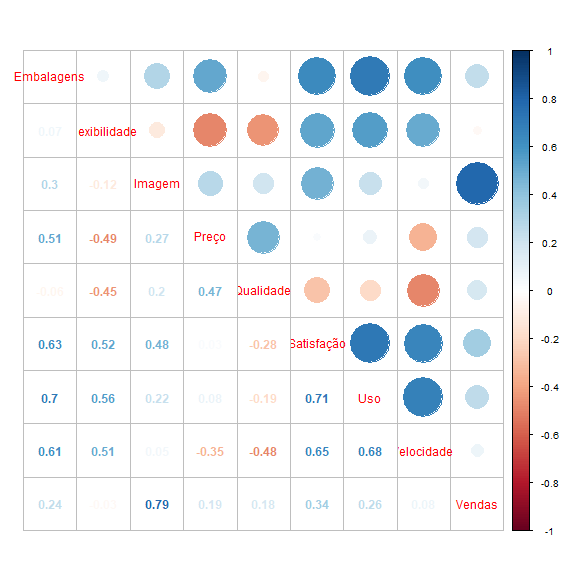

```r
> corrplot.mixed(M)
```

### Gráfico 2 - Diagrama de dispersão Satisfação x Uso

A variável “satisfação” é a que exerce maior influência sobre o uso (71%). Foi feito um diagrama de dispersão para analisar essa relação. Concluímos que quanto maior a satisfação do cliente, maior será a probabilidade de que ele realizará a compra em determinada empresa. Portanto um dos focos de investimento é gerar satisfação aos nossos clientes (a partir desse norte é necessário aprofundar o que gera essa satisfação, garantia? Bom atendimento? Descontos?)

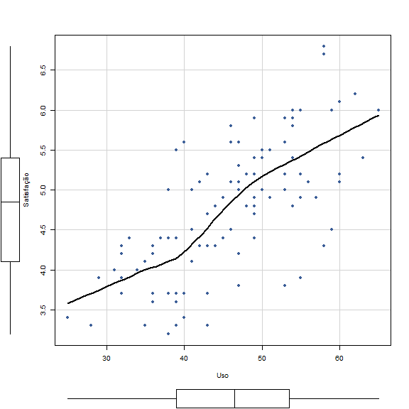

```r
> scatterplot(Satisfação~Uso, reg.line=FALSE, smooth=TRUE, spread=FALSE, boxplots='xy',
+   span=0.5, ellipse=FALSE, levels=c(.5, .9),pch=19,col=c("#872b21",1,"#395c96"),
+   data=HATCO)
```

### Gráfico 3 - Boxplot Satisfação x Empresa

Um outro dado importante é que as empresas menores geraram maior satisfação aos seus clientes do que as empresas grandes. Isso pode se dar por um atendimento mais próximo, personalizado e rápido. As diferenças apresentadas nos dados da base são significantes. Portanto é preciso entender como as empresas pequenas tem atendido seus clientes e como as empresas grandes tem negligenciado as necessidades deles.

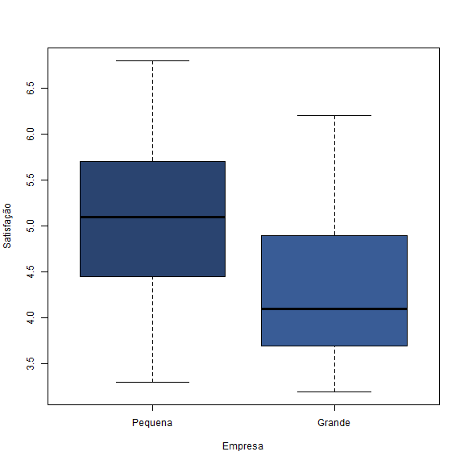

```r
> Boxplot(Satisfação~Empresa, data=HATCO, id.method="y",col=c("#2a4470","#395c96"))
```

A satisfação tem se mostrado tão efetiva ao ponto de levar as empresas pequenas a venderem mais do que as empresas grandes. Ou seja, por mais que uma grande rede possa ter melhores preços, fluxos e processos os clientes que compram celulares tem outras necessidades a serem alcançadas. Portanto as vendas nas pequenas empresas se mostraram maiores do que nas empresas grandes.

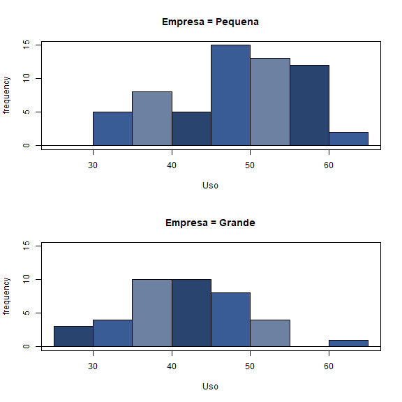

```r
> with(HATCO, Hist(Uso, groups=Empresa, scale="frequency", breaks="Sturges",
+   col=c("#2a4470","#395c96","#6d81a3")))
```

### Gráfico 5 - Boxplot Uso x Sexo

A partir dessas informações focamos em analisar o perfil do consumidor e saber se valeria investir em algum setor específico. Ao analisar a relação entre homem e mulher percebemos que a compra não é afetada pelo sexo do comprador. Portanto não cremos ser efetivo uma campanha de marketing direcionada a somente um dos gêneros.

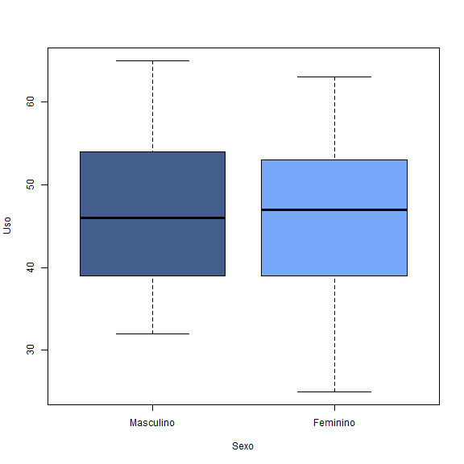

```r
> Boxplot(Uso~Sexo, data=HATCO, id.method="y",col=c("#435e8c","#77a8f9"))
```

### Gráfico 6 - Boxplot Uso x Local

Ao analisar a localidade do consumidor averiguamos que os compradores das cidades do interior são os mais assíduos e paralelamente são os que mais compram em pequenas empresas, mostrando a força local das mesmas. Por isso uma das linhas de investimento deve ser o consumidor do interior que utiliza as pequenas empresas para adquirir seus celulares. O retorno nas capitais se mostrou bem menor do que o do Interior. É possível perceber a presença de somente um “outlier”, mas que não representa a realidade da amostra.

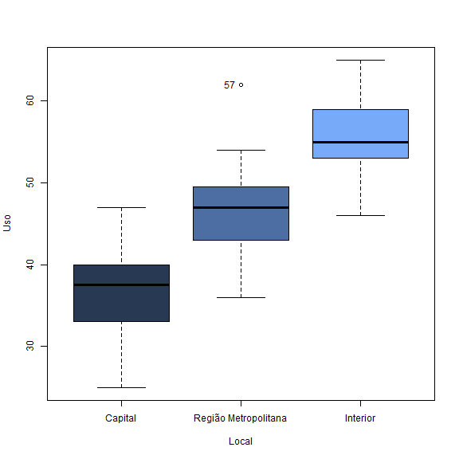

```
[1] "57"
```

```r
> Boxplot(Uso~Local, data=HATCO, id.method="y",col=c("#283954","#4c6ea3","#77aaf9"))
```

### Gráfico 7 - Boxplot Uso x Internet

A outra variável analisada foi se o comprador está acostumado a usar a internet ou não, averiguamos que os que já estão familiarizados acabam comprando mais, ainda que essa diferença não seja extremamente grande. Portanto o foco deve ser ter um ataque duplo aos consumidores. Agindo tanto para os utilizadores de internet assíduos, mas não deixando de conquistar usuários eventuais.

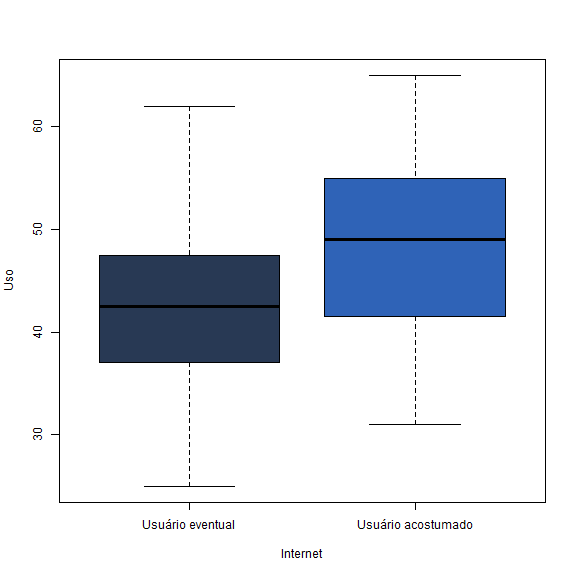

```r
> Boxplot(Uso~Internet, data=HATCO, id.method="y", col=c("#283954","#2f63b7"))
```

### Gráfico 8 – Boxplot Uso x Idade

O último dado sobre perfil do consumidor analisado foi a sua idade, se o mesmo era jovem ou adulto. A base de dados nos sinalizou que os usuários mais jovens são os que mais compram celulares, seguidos pelos adultos. Portanto uma abordagem mais jovial pode mostrar resultados positivos nas ações de marketing, justificado pela sua maior presença como compradores.

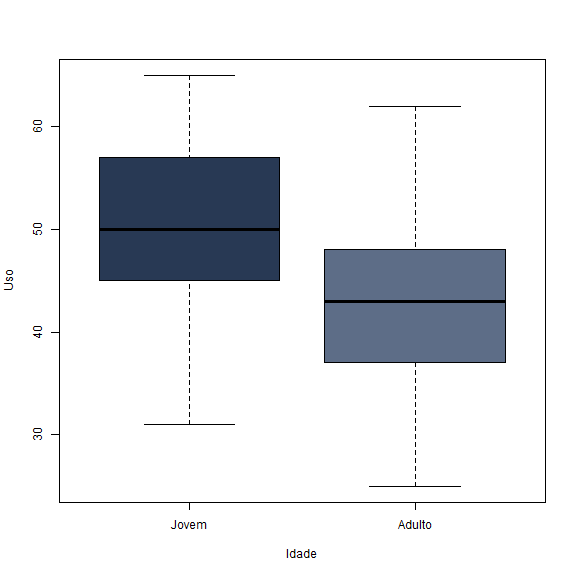

```r
> Boxplot(Uso~Idade, data=HATCO, id.method="y", col=c("#283954","#5d6d87"))
```

## 4- Considerações finais/ Recomendação

Após a análise nós descartamos algumas variáveis que tomariam muito investimento, tempo e energia sem trazer retorno satisfatório. Portanto nossa análise seguiu focada na embalagem, satisfação, velocidade e flexibilidade. O maior foco ficou sobre a satisfação que o cliente sente ao comprar um produto com a empresa, por ser a variável com maior nível de correlação com a variável “USO” que faz menção das compras. Em relação aos consumidores o público que daria o maior retorno possível seria o de jovens, acostumados a usar a internet, que moram no interior e fazem sua compra através das pequenas empresas, independentemente do sexo. Sugerimos que o foco da empresa seja alcançar esse consumidor, levando em conta também a importância da embalagem, flexibilidade de pagamento e a velocidade da entrega, além da satisfação. Baseado nessa análise, fornecemos ao setor de marketing informações para entender melhor seu consumidor e direcionar suas estratégias e ações afim de ter um retorno satisfatório.